# Lab_6

Ethan Rutledge

10/20/2021

Q1. Show the R code you used to define your sse_mean() function.

```r
#rm(list = ls())
require(palmerpenguins)
require(here)
sse_mean = function(x)
    { na.x = is.na(x)
      x2 =  x[!na.x]
      sd.x2 = sd(x2)
      n = length(x2)
       sse = sd.x2/(sqrt(n))
       return(sse)
        }


sse_mean(penguins$body_mass_g)
```

```
## [1] 43.36473
```

```r
sse_mean(mtcars$mpg)
```

```
## [1] 1.065424
```

Q2. Include the code you used to define your two_group_resample() function into the text input

```r
dat_pen = droplevels(subset(penguins, species != "Gentoo"))

x = dat_pen$flipper_length_mm
n_1 = 68
n_2 = 152


two_group_resample = function(x, n_1, n_2)
  {
  dat_1 = sample(x, n_1, replace = TRUE)
  dat_2 = sample(x, n_2, replace = TRUE)


diff_simulated =
  mean(dat_1, na.rm = TRUE) - mean(dat_2, na.rm = TRUE)


return(diff_simulated)
}

set.seed(54321)
two_group_resample(dat_pen$flipper_length_mm, 68, 152)
```

```
## [1] 2.123452
```

```r
t_test_1 = t.test(dat_pen$flipper_length_mm ~ dat_pen$species)
t_test_1
```

```
##
##  Welch Two Sample t-test
##
## data:  dat_pen$flipper_length_mm by dat_pen$species
## t = -5.7804, df = 119.68, p-value = 6.049e-08
## alternative hypothesis: true difference in means between group Adelie and group Chinstrap is not equal to 0
## 95 percent confidence interval:
##  -7.880530 -3.859244
## sample estimates:
##    mean in group Adelie mean in group Chinstrap
##                189.9536                195.8235
```

Q3. Does your function perform Monte Carlo or bootstrap resampling, i.e. does it simulate a null or an alternative hypothesis? You may want to review your answer after you complete the rest of the lab questions.

Our function performs Monte Carlo because it breaks the association between flipper length and species label. Entire columns are jumbled, this tests the null hypothesis.

Q4. Create histogram of the resampled differences of means

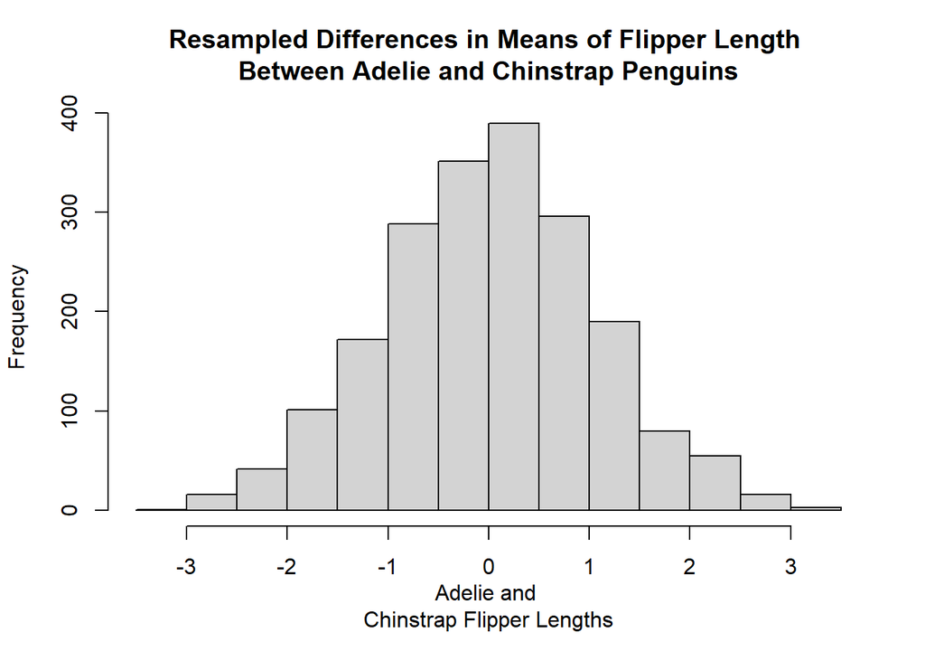

```r
dat_pen = droplevels(subset(penguins, species != "Gentoo"))


x = dat_pen$flipper_length_mm
n_1 = 68
n_2 = 152


two_group_resample = function(x, n_1, n_2)
  {
  dat_1 = sample(x, n_1, replace = TRUE)
  dat_2 = sample(x, n_2, replace = TRUE)


diff_simulated =
  mean(dat_1, na.rm = TRUE) - mean(dat_2, na.rm = TRUE)
}

n = 2000
mean_differences = c()
for (i in 1:n)
{
  mean_differences = c(
    mean_differences,
    two_group_resample(dat_pen$flipper_length_mm, 68, 152)
  )
}
hist(mean_differences, main = "Resampled Differences in Means of Flipper Length \nBetween Adelie and Chinstrap Penguins", ylab = "Frequency" , xlab = "Adelie and \nChinstrap Flipper Lengths")
```

Q5 (6 pts.): How many of your resampled differences of means were greater than 5.8? Assume that we are doing a 2-sided test: we don’t care which species has longer flippers, we only want to know if they are different. Include the R code you used to check the number of differences greater than 5.8.

```r
sum(abs(mean_differences) >= 5.8)
```

```
## [1] 0
```

Q6. Given a p value of less than 1 per 10 million, how many simulations do you think you would have to do to see a difference in mean flipper length equal to or greater than 5.8 mm?

It could be 10 million times though the number could be a lot greater, or infinity.

Q7. Include a boxplot of your chosen variable in your report.

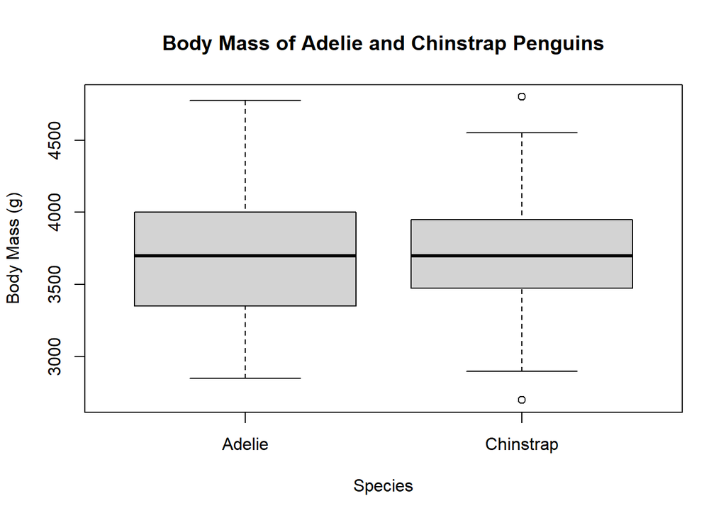

```r
dat_pen = droplevels(subset(penguins, species != "Gentoo"))
{
  boxplot(body_mass_g ~ species, data = dat_pen, ylab = "Body Mass (g)", main = "Body Mass of Adelie and Chinstrap Penguins", xlab = "Species" )
}
```

Q8. Report the group means and difference between the means.

```r
agg_means = aggregate(
  body_mass_g ~ species,
  data = dat_pen,
  FUN = "mean",
  na.rm = TRUE)
diff_crit = diff(agg_means[, 2])

agg_means
```

| species | body_mass_g |
| --- | --- |
| Adelie | 3700.662 |
| Chinstrap | 3733.088 |

```r
diff_crit
```

```
## [1] 32.42598
```

```r
t_test = t.test(dat_pen$body_mass_g ~ dat_pen$species)
t_test
```

```
##
##  Welch Two Sample t-test
##
## data:  dat_pen$body_mass_g by dat_pen$species
## t = -0.54309, df = 152.45, p-value = 0.5879
## alternative hypothesis: true difference in means between group Adelie and group Chinstrap is not equal to 0
## 95 percent confidence interval:
##  -150.38481   85.53284
## sample estimates:
##    mean in group Adelie mean in group Chinstrap
##                3700.662                3733.088
```

Q9. Interpret the p-value from the t-test output in plain, non-technical English that a non-statistician would understand.

There is no difference between the body mass of Adelie penguins versus Chinstrap penguins. We could repeatedly, and randomly, sample individual Adelie and Chinstrap penguins from a population, I would expect to observe a difference in mean body mass of 33g or greater in 600 of 1000 experiments.

Q10. How many differences in means were greater than diff_crit? Remember to treat this as a 2-tailed test.

```r
n = 1000
mean_differences2 = c()
for (i in 1:n)
{
  mean_differences2 = c(
    mean_differences2,
    two_group_resample(dat_pen$body_mass_g, 68, 152)
  )
}
  sum(abs(mean_differences2) >= diff_crit)
```

```
## [1] 614
```

Q11. Include a histogram of your simulation results in your report. Make sure it has appropriate title and labels.

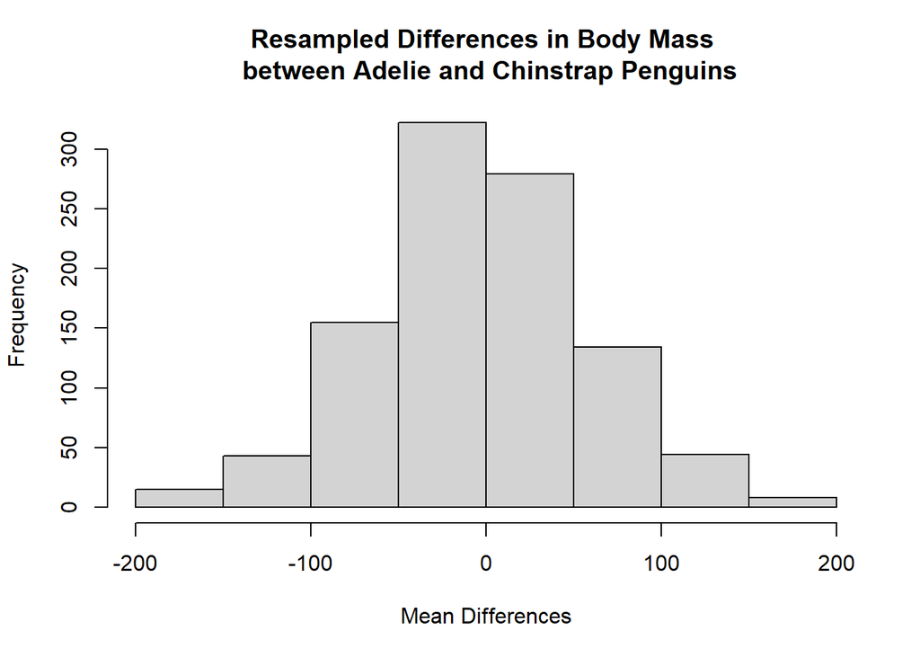

```r
dat_pen = droplevels(subset(penguins, species != "Gentoo"))

x = dat_pen$body_mass_g
n_1 = 68
n_2 = 152


two_group_resample = function(x, n_1, n_2)
  {
  dat_1 = sample(x, n_1, replace = TRUE)
  dat_2 = sample(x, n_2, replace = TRUE)


diff_simulated =
  mean(dat_1, na.rm = TRUE) - mean(dat_2, na.rm = TRUE)
}

n = 1000
mean_differences = c()
for (i in 1:n)
{
  mean_differences = c(
    mean_differences,
    two_group_resample(dat_pen$body_mass_g, 68, 152)
  )
}
hist(mean_differences, main = "Resampled Differences in Body Mass \n between Adelie and Chinstrap Penguins", ylab = "Frequency", xlab = "Mean Differences" )
```